# MAGeCK Comparison Report

Author: Wei Li, weililab.org

## Parameters

comparison_name is the prefix of your output file, defined by the “-n” parameter in your “mageck test” command. The system will look for the following files to generate this report:

- comparison_name.sgrna_summary.txt
- comparison_name.gene_summary.txt
- comparison_name.log

```r
# define the comparison_name here; for example,
# comparison_name='demo'
comparison_name='cd19_1to2_v_Input1_ACT'
```

FDR cutoff is used to draw a boundary line in RRA or p value plots. Set it to -1 to disable the boundary line.

```r
fdrcutoff=0.05
# fdrcutoff=-1 # disable FDR cutoff line
```

## Preprocessing

Reading input files. If any of these files are problematic, an error message will be shown below.

```r
gstable=read.table(gene_summary_file,header = T,as.is = T,na.strings='')
sg_table=read.table(sgrna_summary_file,header = T,as.is = T,na.strings='')
comp_samples=getcomparisonsfromlogfile(log_file)
collabel=c(comp_samples[[1]],comp_samples[[2]])
```

## Summary

The samples used in the comparison is indicated as follows.

Sample summary

| Sample | Type |
| --- | --- |
| Input2_ACT_rep1 | control |
| Input2_ACT_rep2 | control |
| Input2_ACT_rep3 | control |
| amCD19_1to2rep1 | treatment |
| amCD19_1to2rep2 | treatment |
| amCD19_1to2rep3 | treatment |

The statistics of comparisons is as indicated in the following table.

Comparion summary

| Comparison | Genes | Selection | FDR1% | FDR5% | FDR25% |
| --- | --- | --- | --- | --- | --- |
| cd19_1to2_v_Input1_ACT | 1021 | neg | 48 | 86 | 86 |
| cd19_1to2_v_Input1_ACT | 1021 | pos | 15 | 19 | 19 |

The meanings of the columns are as follows.

- Comparison: The label for comparisons;
- Genes: The number of genes in the library;
- Selection: The direction of selection, either positive selection or negative selection;
- FDR1%: The number of genes with FDR < 1%;
- FDR5%: The number of genes with FDR < 5%;
- FDR25%: The number of genes with FDR < 25%;

## Plotting invidivual genes in negative selection

The following figures show:

- Individual sgRNA read counts of selected genes in selected samples;
- The distribution of RRA scores and p values of all genes; and
- The RRA scores and p values of selected genes.

```r
targetgenelist_neg=gstable[gstable[,6]<5,1]

# or, directly specify the genes to be plotted
#targetgenelist_neg=c("ACTR8","ACIN1")

# display genes used in the plot
print(targetgenelist_neg)
```

```
[1] "Ptpn2"  "Stub1"  "Chic2"  "Zfp592"
```

The following figure plots the distribution of RRA scores across these genes. Dotted lines represent the FDR cutoff line defined by the “fdrcutoff” value in the “Paramters” section.

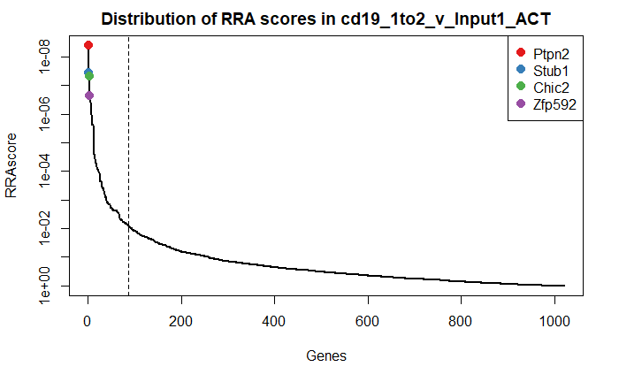

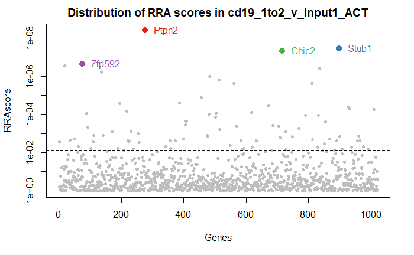

The following figure plots the distribution of p values in these genes. Dotted lines represent the FDR cutoff line defined by the “fdrcutoff” value in the “Paramters” section.

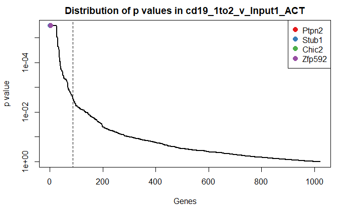

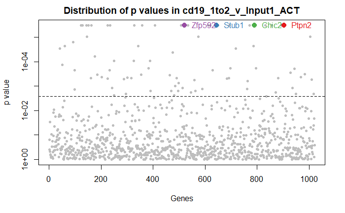

## Plotting invidivual genes in positive selection

```r
targetgenelist_pos=gstable[gstable[,12]<5,1]

# or, directly specify the genes to be plotted
#targetgenelist_pos=c("ACTR8","ACIN1")

# display genes used in the plot
print(targetgenelist_pos)
```

```
[1] "Tsc1"  "Stat1" "Jak1"  "Jak2"
```

The following figure plots the distribution of RRA scores across these genes. Dotted lines represent the FDR cutoff line defined by the “fdrcutoff” value in the “Paramters” section.

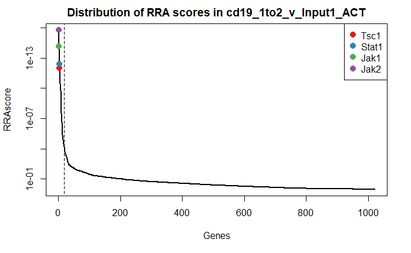

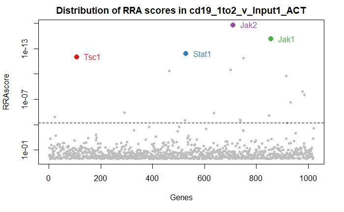

The following figure plots the distribution of p values in these genes. Dotted lines represent the FDR cutoff line defined by the “fdrcutoff” value in the “Paramters” section.

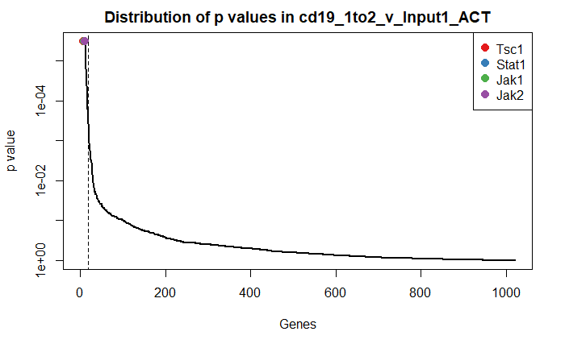

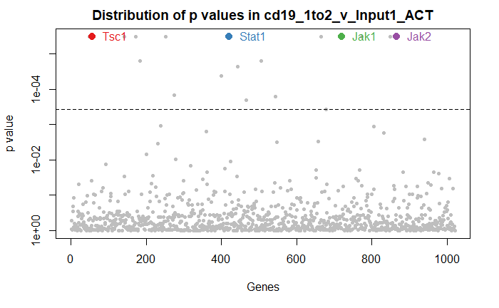

# sgRNA changes

The following figures show the distribution of sgRNA read counts (normalized) of selected genes in selected samples.

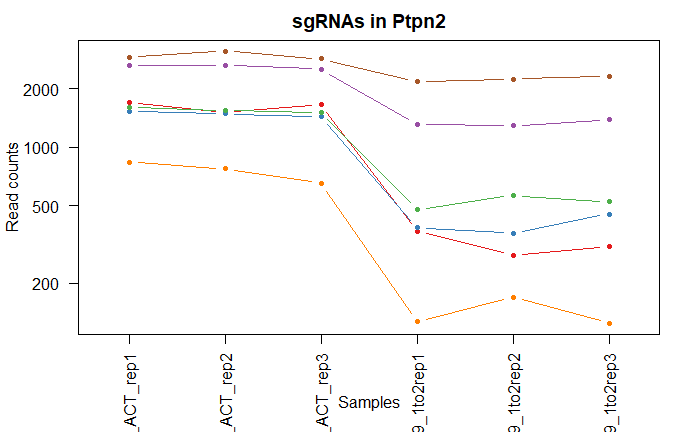

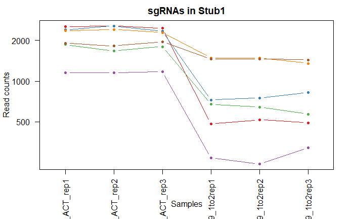

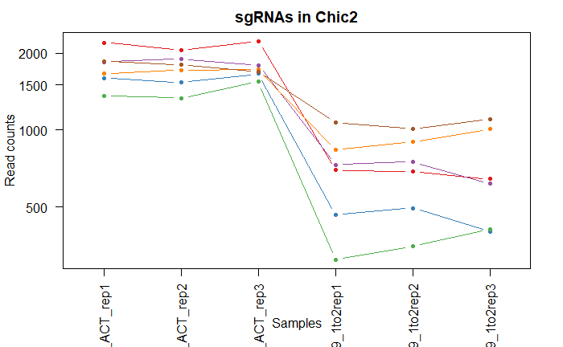

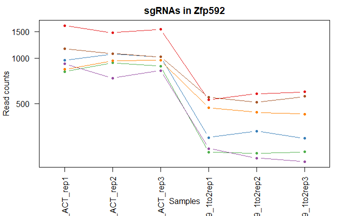

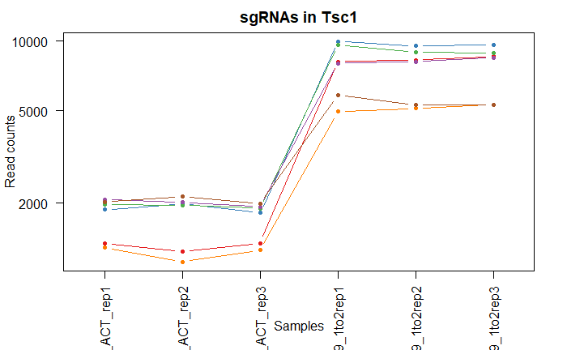

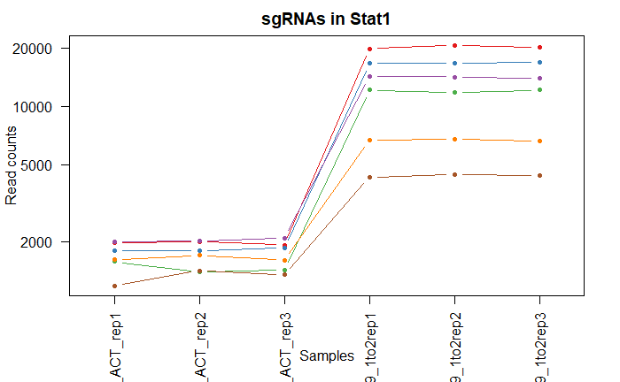

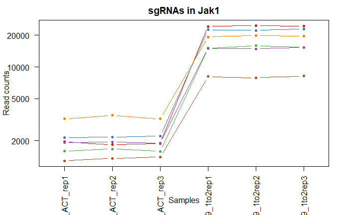

```r
for(target_gene in c(targetgenelist_neg,targetgenelist_pos)){
  plotindvidualsgrnas(sg_table,target_gene,collabel)
}
```

[figure not shown]

```r
NA
```